# SeroTrackR

#### Step 2: Read your data and process MFI to RAU

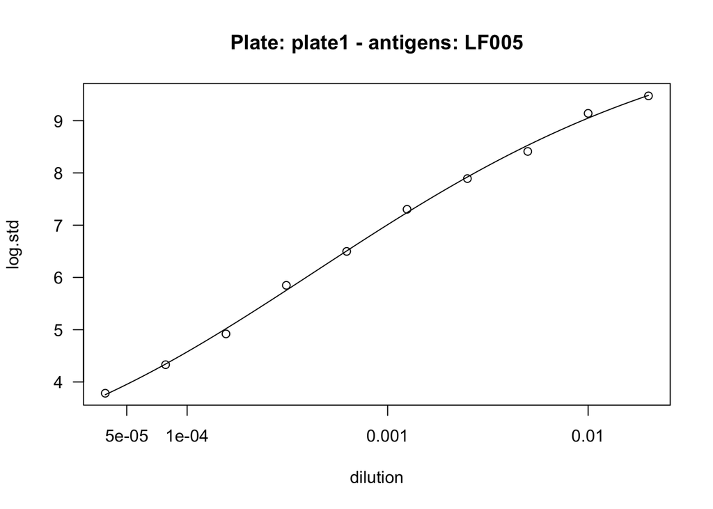

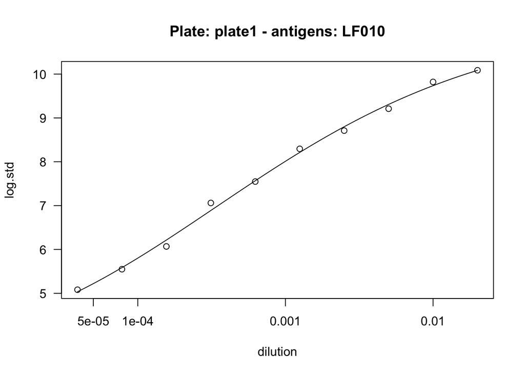

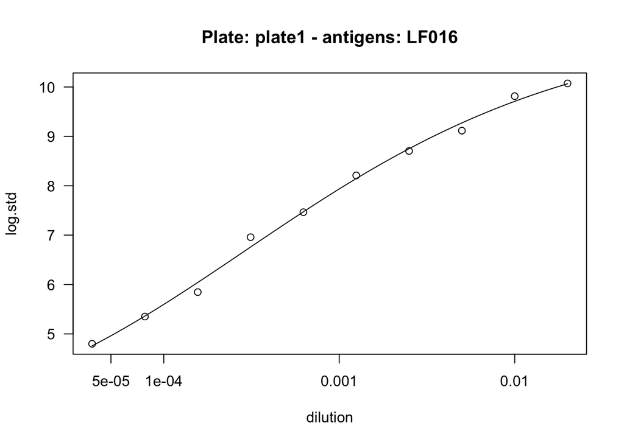

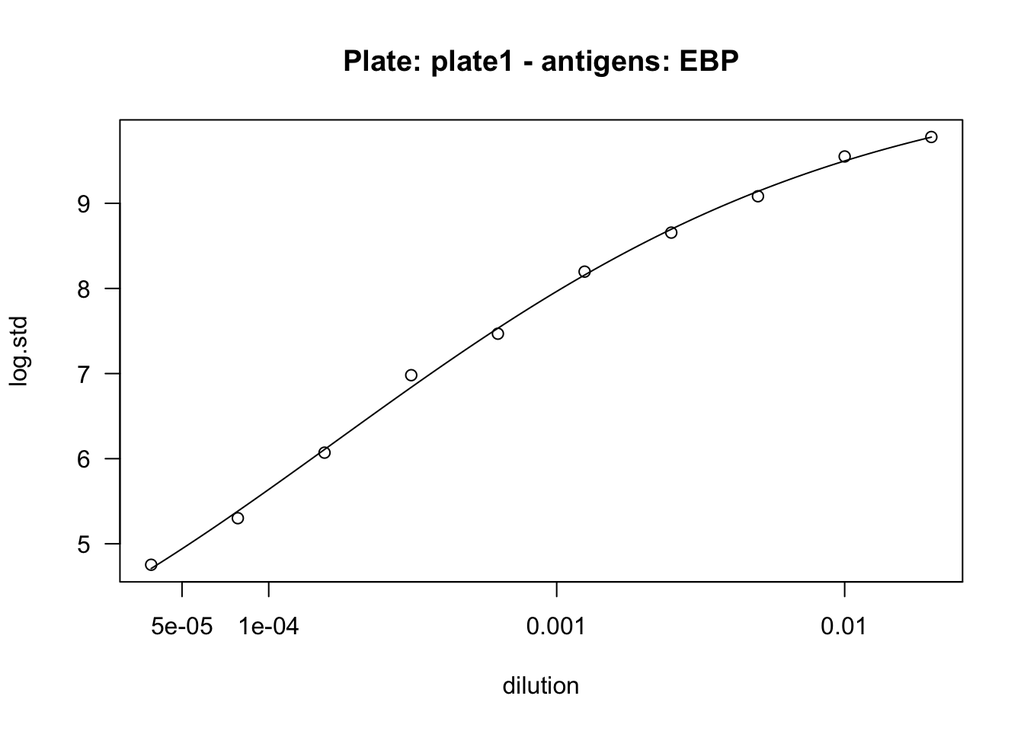

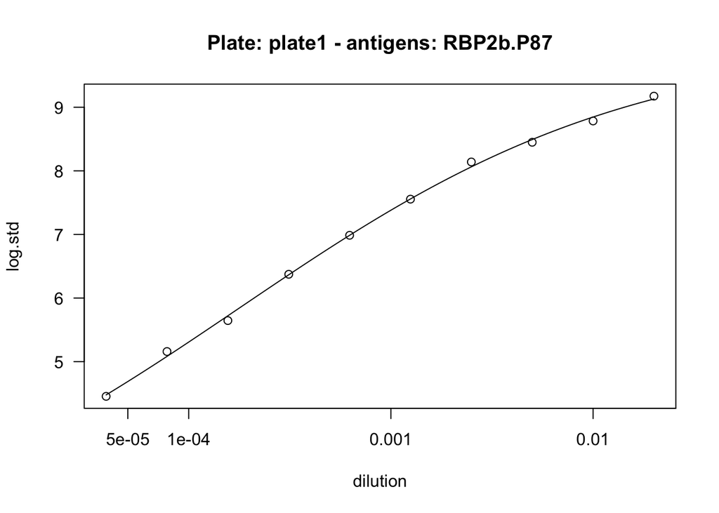

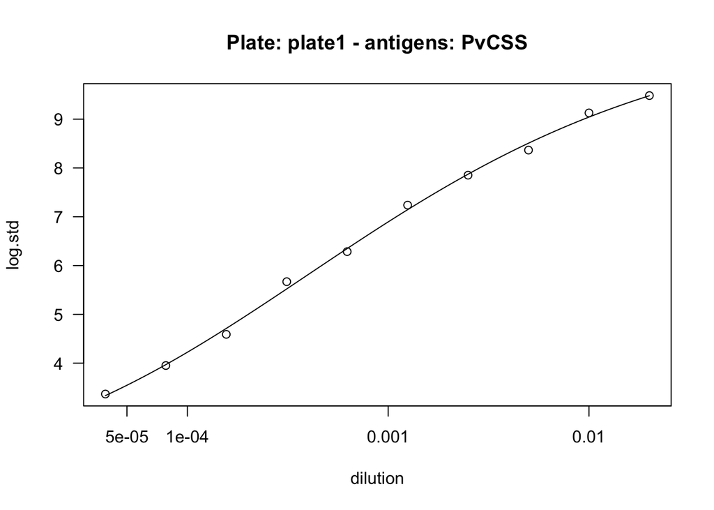

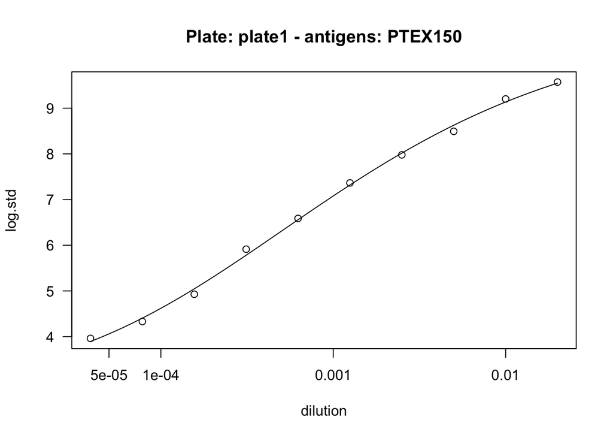

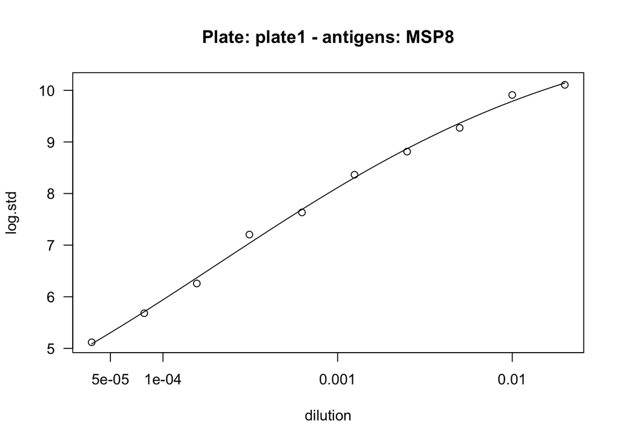

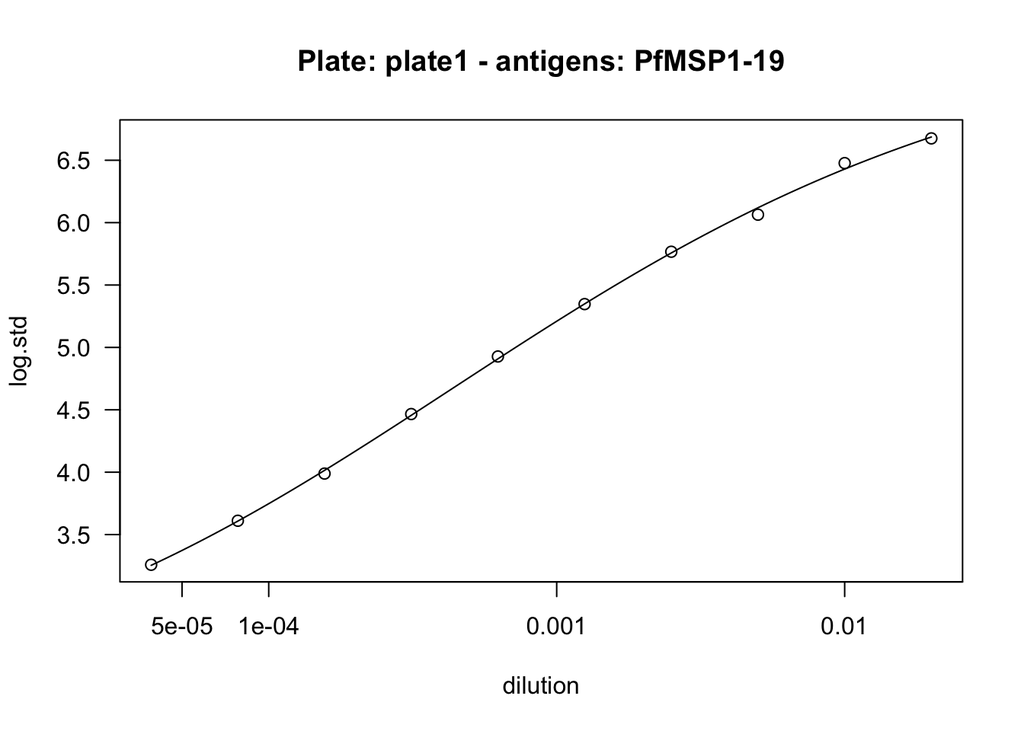

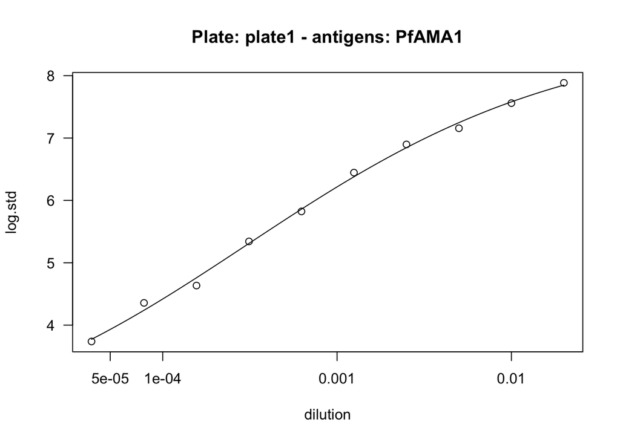

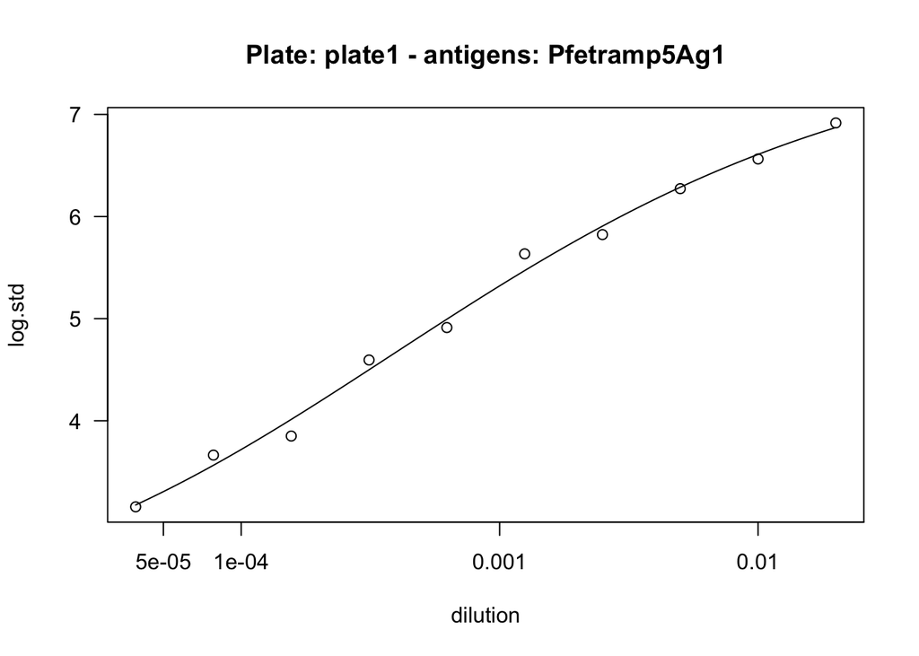

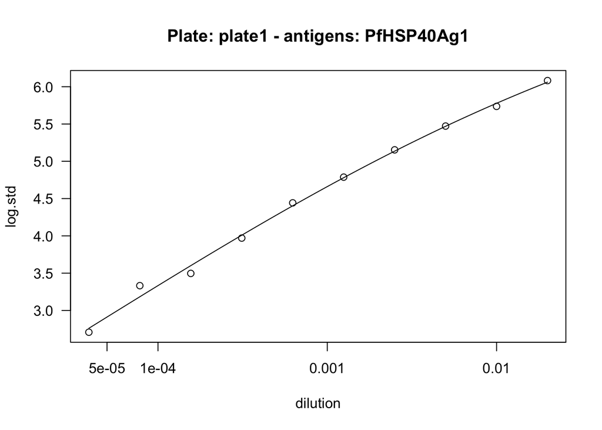

[14 more figures not shown]

```r
results_10stdcurve <- runPlasmoPipeline(
  raw_data = your_raw_data_10std,
  platform = "magpix",
  plate_layout = your_plate_layout_10std,
  panel = "panel1",
  std_point = 10, ################################### here make sure you write 10!
  experiment_name = "10-point standard curve"
)
```

##### Standard Curve Plot

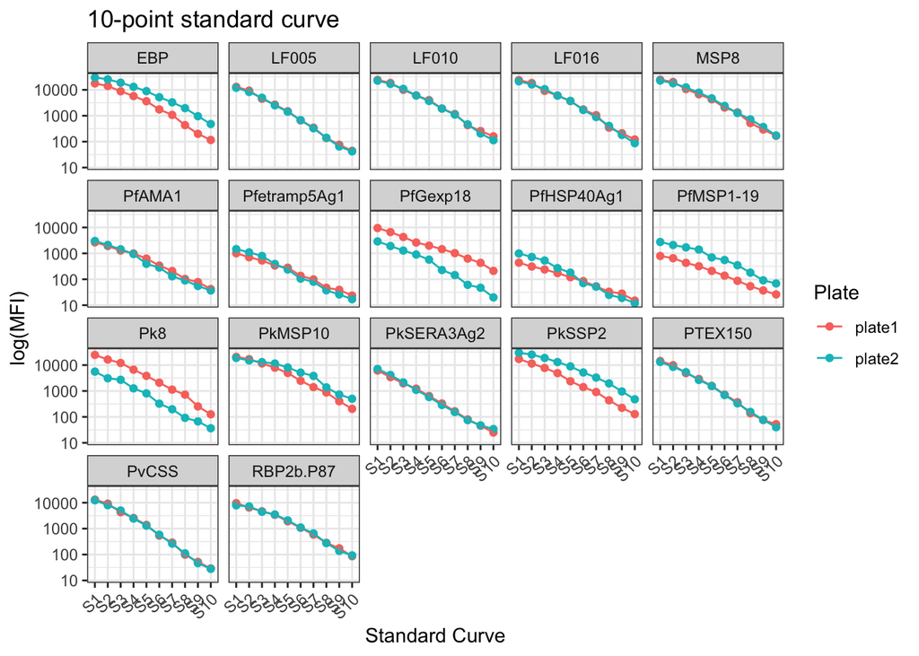

```r
results_10stdcurve$std_curve
```

##### Bead Counts QC Plot

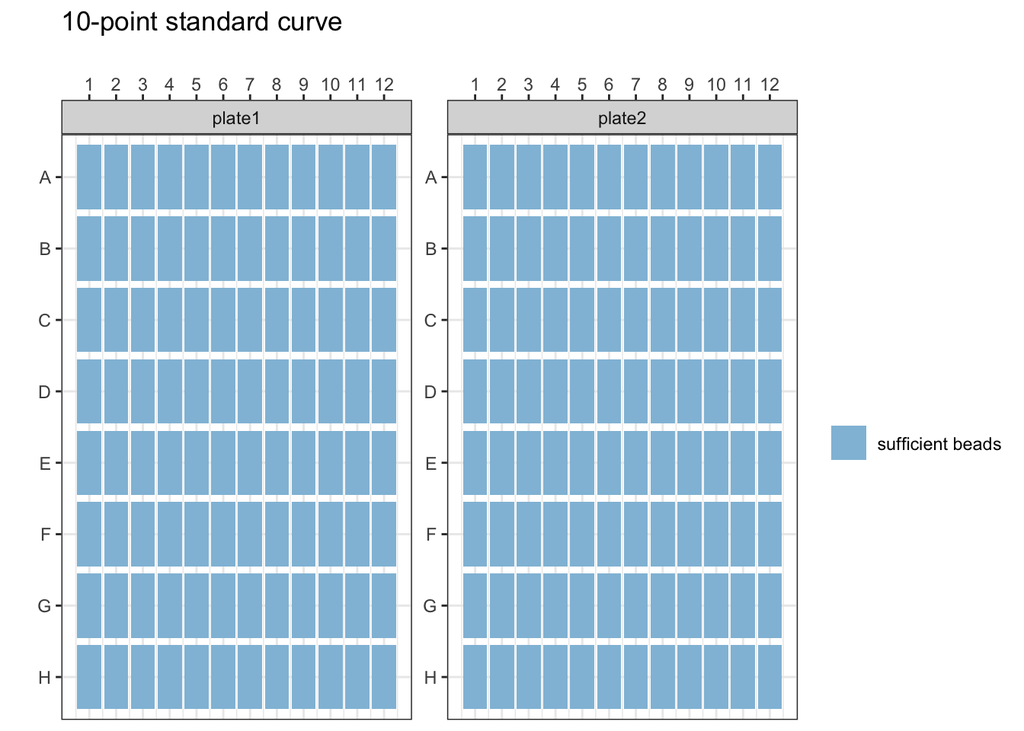

```r
results_10stdcurve$bead_counts
```

##### Blanks QC Ploat

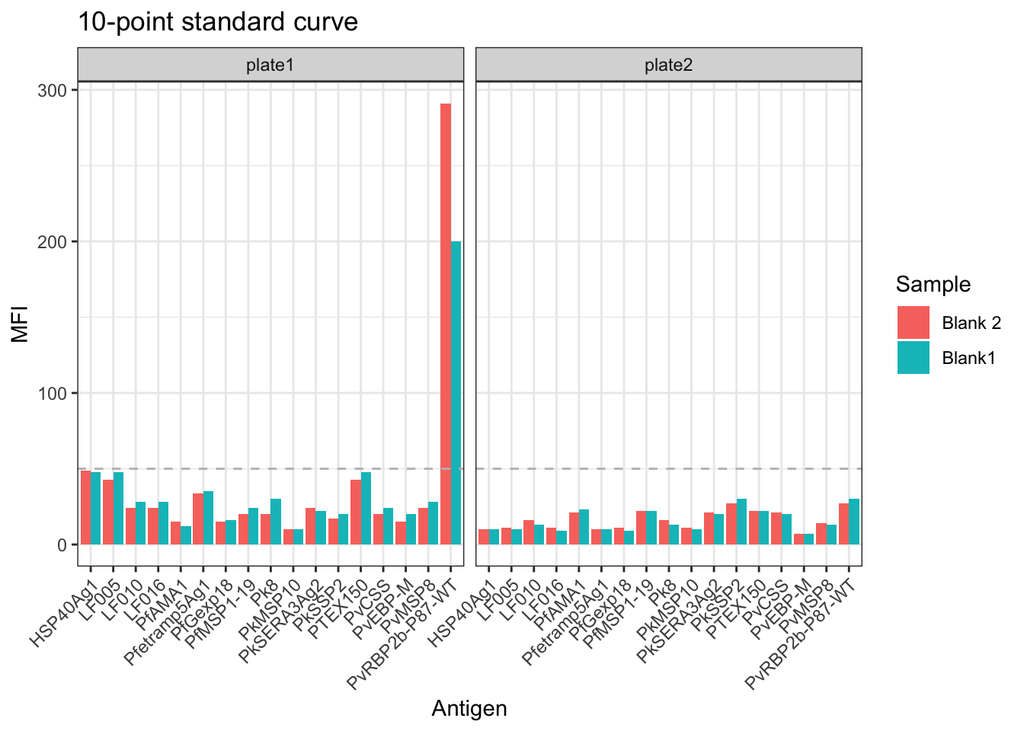

```r
results_10stdcurve$blanks
```

##### MFI to RAU Tables

All results:

```r
results_10stdcurve$mfi_outputs$All_Results %>%
  head() %>%
  kable()
```

| SampleID | Location | Location.2 | Sample | Plate | Pk8_MFI.x | Pk8_log_mfi.x | Pk8_max_s1.x | Pk8_max_dil.x | Pk8_slope.x | Pk8_low_asym.x | Pk8_upp_asym.x | Pk8_ed50.x | Pk8_asym_par.x | Pk8_Dilution.x | Pk8_rau_restricted.x | PkMSP10_MFI.x | PkMSP10_log_mfi.x | PkMSP10_max_s1.x | PkMSP10_max_dil.x | PkMSP10_slope.x | PkMSP10_low_asym.x | PkMSP10_upp_asym.x | PkMSP10_ed50.x | PkMSP10_asym_par.x | PkMSP10_Dilution.x | PkMSP10_rau_restricted.x | PkSERA3Ag2_MFI.x | PkSERA3Ag2_log_mfi.x | PkSERA3Ag2_max_s1.x | … |
| --- | --- | --- | --- | --- | --- | --- | --- | --- | --- | --- | --- | --- | --- | --- | --- | --- | --- | --- | --- | --- | --- | --- | --- | --- | --- | --- | --- | --- | --- | --- |
| ABC-0001 | 25(1,C1) | C1 | Unknown25 | plate1 | 1953.0 | 7.577122 | 10.11523 | 0.02 | -3.9205 | -8.461397 | 8.564957 | 0.0006842 | 0.0163902 | 0.0002717 | 0.0002717 | 1095.0 | 6.998510 | 9.938372 | 0.02 | -3.189242 | 2.674833 | 8.666433 | 0.0005417 | 0.0673263 | 0.0001188 | 0.0001188 | 5761.0 | 8.658866 | 8.724207 | … |
| ABC-0002 | 26(1,C2) | C2 | Unknown26 | plate1 | 492.5 | 6.199495 | 10.11523 | 0.02 | -3.9205 | -8.461397 | 8.564957 | 0.0006842 | 0.0163902 | 0.0000667 | 0.0000667 | 296.5 | 5.692047 | 9.938372 | 0.02 | -3.189242 | 2.674833 | 8.666433 | 0.0005417 | 0.0673263 | 0.0000222 | 0.0000222 | 4583.0 | 8.430109 | 8.724207 | … |
| ABC-0003 | 27(1,C3) | C3 | Unknown27 | plate1 | 136.5 | 4.916325 | 10.11523 | 0.02 | -3.9205 | -8.461397 | 8.564957 | 0.0006842 | 0.0163902 | 0.0000160 | 0.0000195 | 36.0 | 3.583519 | 9.938372 | 0.02 | -3.189242 | 2.674833 | 8.666433 | 0.0005417 | 0.0673263 | 0.0000001 | 0.0000195 | 465.0 | 6.142037 | 8.724207 | … |
| ABC-0004 | 28(1,C4) | C4 | Unknown28 | plate1 | 464.0 | 6.139885 | 10.11523 | 0.02 | -3.9205 | -8.461397 | 8.564957 | 0.0006842 | 0.0163902 | 0.0000626 | 0.0000626 | 688.5 | 6.534515 | 9.938372 | 0.02 | -3.189242 | 2.674833 | 8.666433 | 0.0005417 | 0.0673263 | 0.0000699 | 0.0000699 | 204.0 | 5.318120 | 8.724207 | … |
| ABC-0005 | 29(1,C5) | C5 | Unknown29 | plate1 | 2159.0 | 7.677400 | 10.11523 | 0.02 | -3.9205 | -8.461397 | 8.564957 | 0.0006842 | 0.0163902 | 0.0003004 | 0.0003004 | 1047.5 | 6.954162 | 9.938372 | 0.02 | -3.189242 | 2.674833 | 8.666433 | 0.0005417 | 0.0673263 | 0.0001132 | 0.0001132 | 1563.0 | 7.354362 | 8.724207 | … |
| ABC-0006 | 30(1,C6) | C6 | Unknown30 | plate1 | 313.5 | 5.747799 | 10.11523 | 0.02 | -3.9205 | -8.461397 | 8.564957 | 0.0006842 | 0.0163902 | 0.0000410 | 0.0000410 | 317.0 | 5.758902 | 9.938372 | 0.02 | -3.189242 | 2.674833 | 8.666433 | 0.0005417 | 0.0673263 | 0.0000246 | 0.0000246 | 4176.5 | 8.337229 | 8.724207 | … |

MFI and RAU only:

```r
results_10stdcurve$mfi_outputs$MFI_RAU %>%
  head() %>%
  kable()
```

| SampleID | Plate | LF005_MFI | LF010_MFI | LF016_MFI | EBP_MFI | RBP2b.P87_MFI | PvCSS_MFI | PTEX150_MFI | MSP8_MFI | PfMSP1-19_MFI | PfAMA1_MFI | Pfetramp5Ag1_MFI | PfHSP40Ag1_MFI | PfGexp18_MFI | LF005_PNG_Dilution | LF010_PNG_Dilution | LF016_PNG_Dilution | EBP_PNG_Dilution | RBP2b.P87_PNG_Dilution | PvCSS_PNG_Dilution | PTEX150_PNG_Dilution | MSP8_PNG_Dilution | PfMSP1-19_PNG_Dilution | PfAMA1_PNG_Dilution | Pfetramp5Ag1_PNG_Dilution | PfHSP40Ag1_PNG_Dilution | PfGexp18_PNG_Dilution | EBP_ETH_Dilution | LF005_ETH_Dilution | … |
| --- | --- | --- | --- | --- | --- | --- | --- | --- | --- | --- | --- | --- | --- | --- | --- | --- | --- | --- | --- | --- | --- | --- | --- | --- | --- | --- | --- | --- | --- | --- |
| ABC-0001 | plate1 | 1020 | 1987.0 | 5070 | 3140 | 15170.0 | 672.0 | 1350 | 1751.0 | 1221 | 873.5 | 1058.0 | 863.0 | 2303.0 | 0.0009253 | 0.0006430 | 0.0019247 | 0.0011045 | 0.0200000 | 0.0007170 | 0.0011268 | 0.0004915 | 0.0200000 | 0.0022293 | 0.0200000 | 0.0200000 | 0.0014824 | 0.0005117 | 0.0010659 | … |
| ABC-0002 | plate1 | 329 | 369.5 | 521 | 346 | 778.0 | 264.5 | 500 | 324.0 | 364 | 366.0 | 462.5 | 368.5 | 1003.5 | 0.0003249 | 0.0001129 | 0.0001925 | 0.0001220 | 0.0004303 | 0.0003276 | 0.0004604 | 0.0000843 | 0.0032324 | 0.0006607 | 0.0037558 | 0.0136927 | 0.0003599 | 0.0000385 | 0.0003910 | … |
| ABC-0003 | plate1 | 64 | 50.0 | 113 | 45 | 726.0 | 101.5 | 1124 | 52.0 | 66 | 75.0 | 64.0 | 60.0 | 137.0 | 0.0000636 | 0.0000195 | 0.0000376 | 0.0000195 | 0.0003985 | 0.0001440 | 0.0009516 | 0.0000195 | 0.0002067 | 0.0000872 | 0.0001931 | 0.0003624 | 0.0000195 | 0.0000195 | 0.0000557 | … |
| ABC-0004 | plate1 | 777 | 4357.0 | 273 | 998 | 2673.0 | 213.0 | 425 | 3718.0 | 251 | 876.0 | 275.0 | 227.0 | 499.0 | 0.0007169 | 0.0015099 | 0.0001012 | 0.0003335 | 0.0019523 | 0.0002732 | 0.0003983 | 0.0011290 | 0.0016733 | 0.0022392 | 0.0015644 | 0.0045481 | 0.0001171 | 0.0001404 | 0.0008412 | … |
| ABC-0005 | plate1 | 1434 | 2218.0 | 2318 | 3161 | 14703.5 | 1764.5 | 1730 | 3042.5 | 903 | 696.5 | 1259.0 | 765.0 | 1867.0 | 0.0012836 | 0.0007213 | 0.0008246 | 0.0011130 | 0.0200000 | 0.0016961 | 0.0014239 | 0.0008983 | 0.0200000 | 0.0015867 | 0.0200000 | 0.0200000 | 0.0010264 | 0.0005156 | 0.0014398 | … |
| ABC-0006 | plate1 | 173 | 244.5 | 1211 | 717 | 1808.0 | 164.0 | 242 | 640.0 | 292 | 243.0 | 243.0 | 213.5 | 410.0 | 0.0001778 | 0.0000706 | 0.0004335 | 0.0002429 | 0.0011610 | 0.0002188 | 0.0002389 | 0.0001721 | 0.0021690 | 0.0003928 | 0.0012933 | 0.0039935 | 0.0000862 | 0.0000975 | 0.0002066 | … |

MFI and RAU long table:

```r
results_10stdcurve$mfi_outputs$MFI_RAU_long %>%
  head() %>%
  kable()
```

| SampleID | Plate | Antigens | MFI | Species | Beads | RAU |
| --- | --- | --- | --- | --- | --- | --- |
| ABC-0001 | plate1 | LF005 | 1020 | Pv | PNG | 0.0009253 |
| ABC-0001 | plate1 | LF005 | 1020 | Pv | ETH | 0.0010659 |
| ABC-0001 | plate1 | LF010 | 1987 | Pv | PNG | 0.0006430 |
| ABC-0001 | plate1 | LF010 | 1987 | Pv | ETH | 0.0005896 |
| ABC-0001 | plate1 | LF016 | 5070 | Pv | PNG | 0.0019247 |
| ABC-0001 | plate1 | LF016 | 5070 | Pv | ETH | 0.0165594 |

## Data Analysis: LDH

For the LDH data analysis, follow the steps below:

```r
runLDHpipeline(
  raw_data = "your/raw/data.xlsx",                    # Mandatory
  plate_layout = "your/plate/layout/file.xlsx",       # Mandatory
  platform = "bioplex",                               # Defaults to "bioplex" but "magpix" also works
  location = "ETH",                                   # Defaults to "ETH" but "PNG" also works
  dilution = c(1000000, 333333.33, 111111.11, 37037.04, 12345.68, 4115.23, 1371.74, 457.25, 152.42, 50.81), # Default values shown but other levels can be added
  experiment_name = "experiment1",                    # Defaults to "experiment1"
  file_path = NULL                                    # Defaults to current folder/working directory
)
```

## Visualisation of the `{SeroTrackR}` R Package

We have used the `{targets}` R package to generate a pipeline! This allows us to:

- Automatically detect the dependencies of each step
- One-command execution
- Automatic caching
- Automatic detection of changes in data and/or code

For more information on `{targets}` see this [tutorial](https://books.ropensci.org/targets/).

```
here() starts at /Users/Dionne/Documents/GitHub/SeroTrackR
✔ skipped pipeline [43ms, 15 skipped]
Warning message:
```

```
here() starts at /Users/Dionne/Documents/GitHub/SeroTrackR
Warning message:
```

[interactive chart not shown]

## FAQs

### I have multiple plate layout files. How can I input them?

Use the `getPlateLayout()` function to create a master plate layout file to then input into the other functions in the package!

```r
getPlateLayout("../inst/extdata/")
```

Here replace “../inst/extdata/” with the main file that contains your folders. For example, if your folder looks like this:

```bash
my_R_project/
└── raw_data_files/
    ├── plate_1/
    │   ├── raw_magpix_data_plate1.csv
    │   └── plate_layout_1.xlsx
    ├── plate_2/
    │   ├── raw_magpix_data_plate2.csv
    │   └── plate_layout_2.xlsx
    └── plate_3/
        ├── raw_magpix_data_plate3.csv
        └── plate_layout_3.xlsx
```

you would write:

```r
getPlateLayout("raw_data_files/")
```

you could ALSO write:

```r
getPlateLayout()
```

OR:

```r
getPlateLayout(folder_path = c("plate_layout_1.xlsx", "plate_layout_2.xlsx", "plate_layout_3.xlsx"))
```